# Programowanie w R: Projekt

Zuzanna Juszczak 141238

2022-12-10

## 0.1 Podsumowanie analizy

Raport ten został wykonany w celu przeanalizowania i znalezienia głównych przyczyn stopniowego karłowacenia śledzi oceanicznych wyławianych w Europie.

Najpierw uzupełniono otrzymane dane, dodano rok połowu oraz uzupełniono brakujące wartości. Przedstawiono podstawowe statystyki, analizę rozkładu wartości atrybutów oraz korelację pomiędzy zmiennymi. Zmienne najbardziej skorelowane z długością śledzia to temperatura przy powierzchni wody, oscylacja północnoatlantycka (są one skorelowane negatywnie), poza tym również natężenie połowów w regionie, dostępność określonego rodzaju planktonu *lcop1* (te zmienne są skorelowane dodatnio z długością śledzia). Utworzono 3 regresory z różnymi trzema algorytmami: linear regression, random forest oraz multi-layer perceptron, a następnie wybrano najlepszy z nich.

## 0.2 Wykorzystane biblioteki

```r
library(tidyr)
library(dplyr)
library(zoo)
library(ggplot2)
library(ggcorrplot)
library(gganimate)
library(plotly)
library(caret)
```

## 0.3 Wczytanie danych

```r
fishes <- read.csv("sledzie.csv")
knitr::kable(head(fishes))
```

| X | length | cfin1 | cfin2 | chel1 | chel2 | lcop1 | lcop2 | fbar | recr | cumf | totaln | sst | sal | xmonth | nao |
| --- | --- | --- | --- | --- | --- | --- | --- | --- | --- | --- | --- | --- | --- | --- | --- |
| 0 | 23.0 | 0.02778 | 0.27785 | 2.46875 | ? | 2.54787 | 26.35881 | 0.356 | 482831 | 0.3059879 | 267380.8 | 14.3069330186 | 35.51234 | 7 | 2.8 |
| 1 | 22.5 | 0.02778 | 0.27785 | 2.46875 | 21.43548 | 2.54787 | 26.35881 | 0.356 | 482831 | 0.3059879 | 267380.8 | 14.3069330186 | 35.51234 | 7 | 2.8 |
| 2 | 25.0 | 0.02778 | 0.27785 | 2.46875 | 21.43548 | 2.54787 | 26.35881 | 0.356 | 482831 | 0.3059879 | 267380.8 | 14.3069330186 | 35.51234 | 7 | 2.8 |
| 3 | 25.5 | 0.02778 | 0.27785 | 2.46875 | 21.43548 | 2.54787 | 26.35881 | 0.356 | 482831 | 0.3059879 | 267380.8 | 14.3069330186 | 35.51234 | 7 | 2.8 |
| 4 | 24.0 | 0.02778 | 0.27785 | 2.46875 | 21.43548 | 2.54787 | 26.35881 | 0.356 | 482831 | 0.3059879 | 267380.8 | 14.3069330186 | 35.51234 | 7 | 2.8 |
| 5 | 22.0 | 0.02778 | 0.27785 | 2.46875 | 21.43548 | 2.54787 | ? | 0.356 | 482831 | 0.3059879 | 267380.8 | 14.3069330186 | 35.51234 | 7 | 2.8 |

### 0.3.1 Poprawne wczytanie brakujących danych

Powyżej widzimy, że zbiór zawiera brakujące dane (znaki **?**). Wczytamy więc dane jeszcze raz, ale tym razem z poprawnie określonym parametrem określającym wartości brakujące. Usuniemy również pierwszą kolumnę, ponieważ nie wnosi ona żadnych informacji (jest to liczba porządkowa).

```r
fishes <- read.csv("sledzie.csv", na.strings = "?")
fishes <- fishes[-1]
knitr::kable(head(fishes))
```

| length | cfin1 | cfin2 | chel1 | chel2 | lcop1 | lcop2 | fbar | recr | cumf | totaln | sst | sal | xmonth | nao |
| --- | --- | --- | --- | --- | --- | --- | --- | --- | --- | --- | --- | --- | --- | --- |
| 23.0 | 0.02778 | 0.27785 | 2.46875 | NA | 2.54787 | 26.35881 | 0.356 | 482831 | 0.3059879 | 267380.8 | 14.30693 | 35.51234 | 7 | 2.8 |
| 22.5 | 0.02778 | 0.27785 | 2.46875 | 21.43548 | 2.54787 | 26.35881 | 0.356 | 482831 | 0.3059879 | 267380.8 | 14.30693 | 35.51234 | 7 | 2.8 |
| 25.0 | 0.02778 | 0.27785 | 2.46875 | 21.43548 | 2.54787 | 26.35881 | 0.356 | 482831 | 0.3059879 | 267380.8 | 14.30693 | 35.51234 | 7 | 2.8 |
| 25.5 | 0.02778 | 0.27785 | 2.46875 | 21.43548 | 2.54787 | 26.35881 | 0.356 | 482831 | 0.3059879 | 267380.8 | 14.30693 | 35.51234 | 7 | 2.8 |
| 24.0 | 0.02778 | 0.27785 | 2.46875 | 21.43548 | 2.54787 | 26.35881 | 0.356 | 482831 | 0.3059879 | 267380.8 | 14.30693 | 35.51234 | 7 | 2.8 |
| 22.0 | 0.02778 | 0.27785 | 2.46875 | 21.43548 | 2.54787 | NA | 0.356 | 482831 | 0.3059879 | 267380.8 | 14.30693 | 35.51234 | 7 | 2.8 |

## 0.4 Przetworzenie brakujących danych

### 0.4.1 Brakujące dane o roku

Według opisu zbioru danych, dane te pochodzą z pomiarów na przestrzeni 60 lat. Problemem jest jednak fakt, że same dane zawierają jedynie kolumnę określającą miesiąc, a brakuje kolumny określającej rok połowu.

Poniżej przedstawione są założenia potrzebne do wyznaczenia roku:

- kolumna *recr* przedstawia roczny narybek - ponieważ jest to wartość roczna, oznacza to, że wszystkie rekordy z tego samego roku mają tę wartość taką samą i to właśnie na tej podstawie wyznaczymy rok,
- unikalnych wartości *recr* jest 52, czyli z tylu lat będziemy mieli dostępne pomiary,
- problemem jest brak wiedzy odnośnie chronologii danych - zakładamy więc, że pomiary są w kolejności chronologicznej,
- drugim problemem jest przeplatanie się danych o tych samych wartościach rocznego narybku z danymi o innych wartościach, tutaj jednak znowu jako założenie przyjmujemy chronologię danych.

Podsumowując powyższe informacje, rok zostanie wyznaczony na podstawie kolumny *recr* (roczny narybek), każda unikalna wartość tej kolumny to kolejny rok pomiarów, chronologię wyznacza kolejność występowania danych.

```r
years <- unique(fishes$recr)
fishes <- mutate(fishes, year = match(recr, years))
```

### 0.4.2 Analiza brakujących wartości

```r
how_many_na = sum(is.na(fishes))
knitr::kable(summary(fishes))
```

|  | length | cfin1 | cfin2 | chel1 | chel2 | lcop1 | lcop2 | fbar | recr | cumf | totaln | sst | sal | xmonth | nao | year |
| --- | --- | --- | --- | --- | --- | --- | --- | --- | --- | --- | --- | --- | --- | --- | --- | --- |
|  | Min. :19.0 | Min. : 0.0000 | Min. : 0.0000 | Min. : 0.000 | Min. : 5.238 | Min. : 0.3074 | Min. : 7.849 | Min. :0.0680 | Min. : 140515 | Min. :0.06833 | Min. : 144137 | Min. :12.77 | Min. :35.40 | Min. : 1.000 | Min. :-4.89000 | Min. : 1.00 |
|  | 1st Qu.:24.0 | 1st Qu.: 0.0000 | 1st Qu.: 0.2778 | 1st Qu.: 2.469 | 1st Qu.:13.427 | 1st Qu.: 2.5479 | 1st Qu.:17.808 | 1st Qu.:0.2270 | 1st Qu.: 360061 | 1st Qu.:0.14809 | 1st Qu.: 306068 | 1st Qu.:13.60 | 1st Qu.:35.51 | 1st Qu.: 5.000 | 1st Qu.:-1.89000 | 1st Qu.:10.00 |
|  | Median :25.5 | Median : 0.1111 | Median : 0.7012 | Median : 5.750 | Median :21.673 | Median : 7.0000 | Median :24.859 | Median :0.3320 | Median : 421391 | Median :0.23191 | Median : 539558 | Median :13.86 | Median :35.51 | Median : 8.000 | Median : 0.20000 | Median :19.00 |
|  | Mean :25.3 | Mean : 0.4458 | Mean : 2.0248 | Mean :10.006 | Mean :21.221 | Mean : 12.8108 | Mean :28.419 | Mean :0.3304 | Mean : 520367 | Mean :0.22981 | Mean : 514973 | Mean :13.87 | Mean :35.51 | Mean : 7.258 | Mean :-0.09236 | Mean :21.97 |
|  | 3rd Qu.:26.5 | 3rd Qu.: 0.3333 | 3rd Qu.: 1.7936 | 3rd Qu.:11.500 | 3rd Qu.:27.193 | 3rd Qu.: 21.2315 | 3rd Qu.:37.232 | 3rd Qu.:0.4560 | 3rd Qu.: 724151 | 3rd Qu.:0.29803 | 3rd Qu.: 730351 | 3rd Qu.:14.16 | 3rd Qu.:35.52 | 3rd Qu.: 9.000 | 3rd Qu.: 1.63000 | 3rd Qu.:34.00 |
|  | Max. :32.5 | Max. :37.6667 | Max. :19.3958 | Max. :75.000 | Max. :57.706 | Max. :115.5833 | Max. :68.736 | Max. :0.8490 | Max. :1565890 | Max. :0.39801 | Max. :1015595 | Max. :14.73 | Max. :35.61 | Max. :12.000 | Max. : 5.08000 | Max. :52.00 |
|  | NA | NA’s :1581 | NA’s :1536 | NA’s :1555 | NA’s :1556 | NA’s :1653 | NA’s :1591 | NA | NA | NA | NA | NA’s :1584 | NA | NA | NA | NA |

Problemem jest ilość brakujących danych - w zbiorze znajduje się łącznie aż **11056** brakujących wartości i znajdują się one w kolumnach: *cfin1*, *cfin2*, *chel1*, *chel2*, *lcop1*, *lcop2*, *sst*.

### 0.4.3 Uzupełnienie brakujących wartości

Wyżej wspomniane brakujące wartości uzupełnimy - zastąpimy je wartością średnią pogrupowaną po roku i miesiącu połowu. Pozwoli to nam na w miarę realistyczne odwzorowanie brakujących danych, ponieważ wartości te w przeciągu miesiąca niewiele się zmieniają.

```r
fishes <- fishes %>%
  group_by(year, xmonth) %>%
  mutate_at(vars(cfin1, cfin2, chel1, chel2, lcop1, lcop2, sst), ~replace_na(., mean(., na.rm = TRUE)))

knitr::kable(summary(fishes))
```

|  | length | cfin1 | cfin2 | chel1 | chel2 | lcop1 | lcop2 | fbar | recr | cumf | totaln | sst | sal | xmonth | nao | year |
| --- | --- | --- | --- | --- | --- | --- | --- | --- | --- | --- | --- | --- | --- | --- | --- | --- |
|  | Min. :19.0 | Min. : 0.0000 | Min. : 0.0000 | Min. : 0.000 | Min. : 5.238 | Min. : 0.3074 | Min. : 7.849 | Min. :0.0680 | Min. : 140515 | Min. :0.06833 | Min. : 144137 | Min. :12.77 | Min. :35.40 | Min. : 1.000 | Min. :-4.89000 | Min. : 1.00 |
|  | 1st Qu.:24.0 | 1st Qu.: 0.0000 | 1st Qu.: 0.2778 | 1st Qu.: 2.469 | 1st Qu.:13.427 | 1st Qu.: 2.5479 | 1st Qu.:17.808 | 1st Qu.:0.2270 | 1st Qu.: 360061 | 1st Qu.:0.14809 | 1st Qu.: 306068 | 1st Qu.:13.60 | 1st Qu.:35.51 | 1st Qu.: 5.000 | 1st Qu.:-1.89000 | 1st Qu.:10.00 |
|  | Median :25.5 | Median : 0.1111 | Median : 0.7012 | Median : 5.750 | Median :21.435 | Median : 7.0717 | Median :24.859 | Median :0.3320 | Median : 421391 | Median :0.23191 | Median : 539558 | Median :13.86 | Median :35.51 | Median : 8.000 | Median : 0.20000 | Median :19.00 |
|  | Mean :25.3 | Mean : 0.4457 | Mean : 2.0258 | Mean :10.003 | Mean :21.219 | Mean : 12.8048 | Mean :28.422 | Mean :0.3304 | Mean : 520367 | Mean :0.22981 | Mean : 514973 | Mean :13.87 | Mean :35.51 | Mean : 7.258 | Mean :-0.09236 | Mean :21.97 |
|  | 3rd Qu.:26.5 | 3rd Qu.: 0.3333 | 3rd Qu.: 1.7936 | 3rd Qu.:11.500 | 3rd Qu.:27.193 | 3rd Qu.: 21.2315 | 3rd Qu.:37.232 | 3rd Qu.:0.4560 | 3rd Qu.: 724151 | 3rd Qu.:0.29803 | 3rd Qu.: 730351 | 3rd Qu.:14.16 | 3rd Qu.:35.52 | 3rd Qu.: 9.000 | 3rd Qu.: 1.63000 | 3rd Qu.:34.00 |
|  | Max. :32.5 | Max. :37.6667 | Max. :19.3958 | Max. :75.000 | Max. :57.706 | Max. :115.5833 | Max. :68.736 | Max. :0.8490 | Max. :1565890 | Max. :0.39801 | Max. :1015595 | Max. :14.73 | Max. :35.61 | Max. :12.000 | Max. : 5.08000 | Max. :52.00 |

Jak możemy zauważyć, teraz nasz zbiór nie posiada już brakujących danych i jesteśmy gotowi do dalszej analizy.

## 0.5 Opis kolumn oraz podstawowe statystyki

```r
fishes_dim = dim(fishes)
```

Zbiór zawiera **52582** wierszy oraz **16** kolumn. Kolumny te to:

- *length*: długość złowionego śledzia [cm],
- *cfin1*: dostępność planktonu [zagęszczenie Calanus finmarchicus gat. 1],
- *cfin2*: dostępność planktonu [zagęszczenie Calanus finmarchicus gat. 2],
- *chel1*: dostępność planktonu [zagęszczenie Calanus helgolandicus gat. 1],
- *chel2*: dostępność planktonu [zagęszczenie Calanus helgolandicus gat. 2],
- *lcop1*: dostępność planktonu [zagęszczenie widłonogów gat. 1],
- *lcop2*: dostępność planktonu [zagęszczenie widłonogów gat. 2],
- *fbar*: natężenie połowów w regionie [ułamek pozostawionego narybku],
- *recr*: roczny narybek [liczba śledzi],
- *cumf*: łączne roczne natężenie połowów w regionie [ułamek pozostawionego narybku],
- *totaln*: łączna liczba ryb złowionych w ramach połowu [liczba śledzi],
- *sst*: temperatura przy powierzchni wody [°C],
- *sal*: poziom zasolenia wody [Knudsen ppt],
- *xmonth*: miesiąc połowu [numer miesiąca],
- *nao*: oscylacja północnoatlantycka [mb],
- *year*: rok połowu [liczba porządkowa roku] **(dodatkowa kolumna dodana w trakcie przetwarzania danych)**.

```r
knitr::kable(summary(fishes))
```

|  | length | cfin1 | cfin2 | chel1 | chel2 | lcop1 | lcop2 | fbar | recr | cumf | totaln | sst | sal | xmonth | nao | year |
| --- | --- | --- | --- | --- | --- | --- | --- | --- | --- | --- | --- | --- | --- | --- | --- | --- |
|  | Min. :19.0 | Min. : 0.0000 | Min. : 0.0000 | Min. : 0.000 | Min. : 5.238 | Min. : 0.3074 | Min. : 7.849 | Min. :0.0680 | Min. : 140515 | Min. :0.06833 | Min. : 144137 | Min. :12.77 | Min. :35.40 | Min. : 1.000 | Min. :-4.89000 | Min. : 1.00 |
|  | 1st Qu.:24.0 | 1st Qu.: 0.0000 | 1st Qu.: 0.2778 | 1st Qu.: 2.469 | 1st Qu.:13.427 | 1st Qu.: 2.5479 | 1st Qu.:17.808 | 1st Qu.:0.2270 | 1st Qu.: 360061 | 1st Qu.:0.14809 | 1st Qu.: 306068 | 1st Qu.:13.60 | 1st Qu.:35.51 | 1st Qu.: 5.000 | 1st Qu.:-1.89000 | 1st Qu.:10.00 |
|  | Median :25.5 | Median : 0.1111 | Median : 0.7012 | Median : 5.750 | Median :21.435 | Median : 7.0717 | Median :24.859 | Median :0.3320 | Median : 421391 | Median :0.23191 | Median : 539558 | Median :13.86 | Median :35.51 | Median : 8.000 | Median : 0.20000 | Median :19.00 |
|  | Mean :25.3 | Mean : 0.4457 | Mean : 2.0258 | Mean :10.003 | Mean :21.219 | Mean : 12.8048 | Mean :28.422 | Mean :0.3304 | Mean : 520367 | Mean :0.22981 | Mean : 514973 | Mean :13.87 | Mean :35.51 | Mean : 7.258 | Mean :-0.09236 | Mean :21.97 |
|  | 3rd Qu.:26.5 | 3rd Qu.: 0.3333 | 3rd Qu.: 1.7936 | 3rd Qu.:11.500 | 3rd Qu.:27.193 | 3rd Qu.: 21.2315 | 3rd Qu.:37.232 | 3rd Qu.:0.4560 | 3rd Qu.: 724151 | 3rd Qu.:0.29803 | 3rd Qu.: 730351 | 3rd Qu.:14.16 | 3rd Qu.:35.52 | 3rd Qu.: 9.000 | 3rd Qu.: 1.63000 | 3rd Qu.:34.00 |
|  | Max. :32.5 | Max. :37.6667 | Max. :19.3958 | Max. :75.000 | Max. :57.706 | Max. :115.5833 | Max. :68.736 | Max. :0.8490 | Max. :1565890 | Max. :0.39801 | Max. :1015595 | Max. :14.73 | Max. :35.61 | Max. :12.000 | Max. : 5.08000 | Max. :52.00 |

## 0.6 Analiza wartości atrybutów

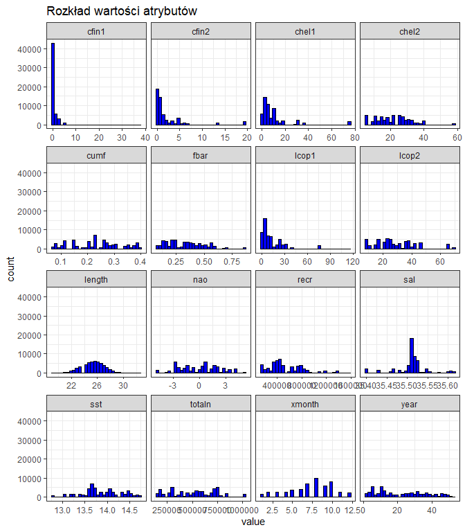

```r
ggplot(gather(fishes), aes(x=value)) +
  geom_histogram(color="black", fill="blue") +
  facet_wrap(~ key, scales = 'free_x') +
  theme_bw() +
  ggtitle("Rozkład wartości atrybutów")
```

## 0.7 Korelacje między zmiennymi

```r
drop <- c("year", "xmonth")
corr_matrix = round(cor(fishes[,!names(fishes) %in% drop]), 2)
```

Przy obliczaniu korelacji pominiemy rok oraz miesiąc połowu, ponieważ tych dwóch kolumn nie chcemy uwzględniać przy wybieraniu atrybutów do utworzenia regresora.

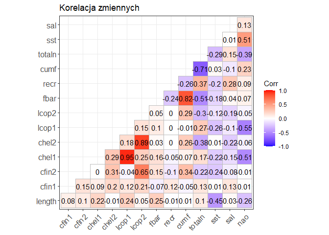

```r
ggcorrplot(corr_matrix,
           type = "lower",
           lab = TRUE,
           title = "Korelacja zmiennych",
           ggtheme=theme_bw)
```

Z powyższego wykresu możemy odczytać, które zmienne są skorelowane ze zmienną *length*. Widzimy, że *length* jest najsilniej skorelowane z:

- *sst* (-0.45) oraz *nao* (-0.26) (korelacja ujemna),
- *fbar* (0.25), *lcop1* (0.24), *chel1* (0.22) (korelacja dodatnia).

Te zmienne weźmiemy pod uwagę przy tworzeniu regresora.

## 0.8 Zmiana rozmiaru śledzi w czasie

[figure not shown]

```r
plot_fishes <- fishes %>% mutate(date = as.Date(as.yearmon(paste(xmonth, " ", year), "%m %Y"))) %>% group_by(date) %>% summarize(length_mean = mean(length))

animation_plot <- ggplot(plot_fishes, aes(x=date, y=length_mean)) + geom_line() +
  labs(x = "Data połowu", y = "Średnia długość śledzia") +
  ggtitle("Zmiana długości śledzia w czasie") +
  theme_bw()

animation_plot + transition_reveal(date)
```

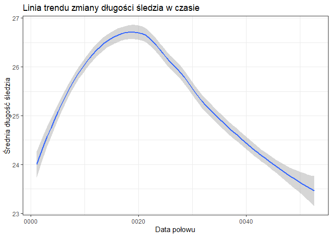

```r
ggplot(plot_fishes, aes(x=date, y=length_mean)) + geom_smooth() +
  labs(x = "Data połowu", y = "Średnia długość śledzia") +
  ggtitle("Linia trendu zmiany długości śledzia w czasie") +
  theme_bw()
```

Na powyższym wykresie można zauważyć linię trendu w odniesieniu do długości śledzia. Zauważamy od pewnego momentu zjawisko karłowacenia śledzi (widzimy tendencję spadkową długości).

## 0.9 Regresor przewidujący rozmiar śledzia

Utworzymy 3 regresory wykorzystując algorytmy:

- **linear regression**,
- **random forest**,
- **multi-layer perceptron**.

Atrybutami użytymi przy regresorze będa atrybuty wyznaczone w punkcie dotyczącym korelacji, tj. *sst*, *nao*, *fbar*, *lcop1* oraz *chel1*. Przy tworzeniu każdego regresora będziemy optymalizować ich parametry, aby uzyskać jak najlepsze wyniki.

### 0.9.1 Przygotowanie zbiorów

```r
in_training <- createDataPartition(y = fishes$length, p=0.75, list=FALSE)
training <- fishes[in_training,]
testing  <- fishes[-in_training,]

ctrl <- trainControl(
    method = "repeatedcv",
    number = 2,
    repeats = 5)
```

### 0.9.2 Linear Regression

#### 0.9.2.1 Zbiór treningowy

```r
lm_model <- train(length ~ sst + nao + fbar + lcop1 + chel1,
             data = training,
             method = "lm",
             preProcess = c("center", "scale"),
             trControl = ctrl,
             tuneGrid = expand.grid(intercept = c(TRUE, FALSE)))

lm_model
```

```
## Linear Regression
##
## 39438 samples
##     5 predictor
##
## Pre-processing: centered (5), scaled (5)
## Resampling: Cross-Validated (2 fold, repeated 5 times)
## Summary of sample sizes: 19720, 19718, 19719, 19719, 19719, 19719, ...
## Resampling results across tuning parameters:
##
##   intercept  RMSE       Rsquared   MAE
##   FALSE      25.344961  0.2472228  25.30431
##    TRUE       1.434893  0.2472228   1.14831
##
## RMSE was used to select the optimal model using the smallest value.
## The final value used for the model was intercept = TRUE.
```

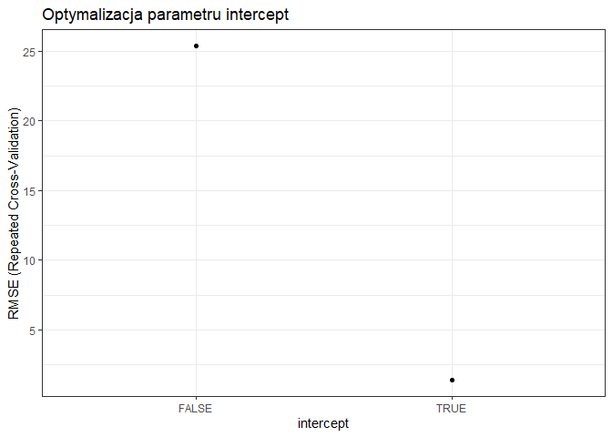

```r
ggplot(lm_model) + geom_line() + geom_point() + ggtitle("Optymalizacja parametru intercept") + theme_bw()
```

#### 0.9.2.2 Zbiór testowy

```r
lm_predicted <- predict(lm_model, testing)
postResample(pred = lm_predicted, obs = testing$length)
```

```
##      RMSE  Rsquared       MAE
## 1.4272071 0.2520731 1.1410587
```

### 0.9.3 Random forest

#### 0.9.3.1 Zbiór treningowy

```r
rf_model <- train(length ~ sst + nao + fbar + lcop1 + chel1,
             data = training,
             method = "rf",
             preProcess = c("center", "scale"),
             trControl = ctrl,
             tuneGrid = expand.grid(mtry = seq(10, 31, by = 2)),
             ntree = 30)

rf_model
```

```
## Random Forest
##
## 39438 samples
##     5 predictor
##
## Pre-processing: centered (5), scaled (5)
## Resampling: Cross-Validated (2 fold, repeated 5 times)
## Summary of sample sizes: 19718, 19720, 19720, 19718, 19719, 19719, ...
## Resampling results across tuning parameters:
##
##   mtry  RMSE      Rsquared   MAE
##   10    1.189343  0.4828047  0.9410041
##   12    1.189314  0.4828331  0.9409814
##   14    1.189414  0.4827449  0.9410011
##   16    1.189422  0.4827362  0.9411082
##   18    1.189449  0.4827052  0.9411458
##   20    1.189347  0.4827935  0.9410196
##   22    1.189302  0.4828393  0.9410473
##   24    1.189240  0.4828947  0.9409106
##   26    1.189347  0.4828007  0.9410684
##   28    1.189339  0.4828036  0.9410458
##   30    1.189454  0.4827104  0.9410729
##
## RMSE was used to select the optimal model using the smallest value.
## The final value used for the model was mtry = 24.
```

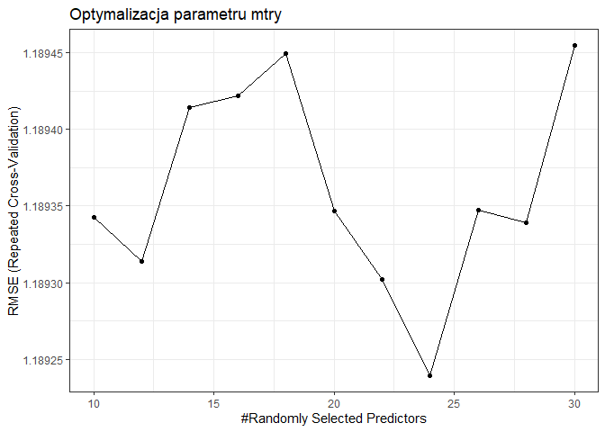

```r
ggplot(rf_model) + geom_line() + geom_point() + ggtitle("Optymalizacja parametru mtry") + theme_bw()
```

#### 0.9.3.2 Zbiór testowy

```r
rf_predicted <- predict(rf_model, testing)
postResample(pred = rf_predicted, obs = testing$length)
```

```
##      RMSE  Rsquared       MAE
## 1.1899705 0.4801970 0.9399368
```

### 0.9.4 Multi-Layer Perceptron

#### 0.9.4.1 Zbiór treningowy

```r
mlp_model <- train(length ~ sst + nao + fbar + lcop1 + chel1,
             data = training,
             method = "mlp",
             preProcess = c("center", "scale"),
             trControl=ctrl,
             tuneGrid = expand.grid(size = seq(1, 11, by = 2)))

mlp_model
```

```
## Multi-Layer Perceptron
##
## 39438 samples
##     5 predictor
##
## Pre-processing: centered (5), scaled (5)
## Resampling: Cross-Validated (2 fold, repeated 5 times)
## Summary of sample sizes: 19719, 19719, 19718, 19720, 19718, 19720, ...
## Resampling results across tuning parameters:
##
##   size  RMSE      Rsquared     MAE
##    1    1.754713  0.002970414  1.416618
##    3    1.574641  0.250712355  1.265360
##    5    1.872744  0.281342461  1.368990
##    7    1.391493  0.368645200  1.106173
##    9    1.509938  0.331350218  1.208876
##   11    1.578865  0.286387844  1.267731
##
## RMSE was used to select the optimal model using the smallest value.
## The final value used for the model was size = 7.
```

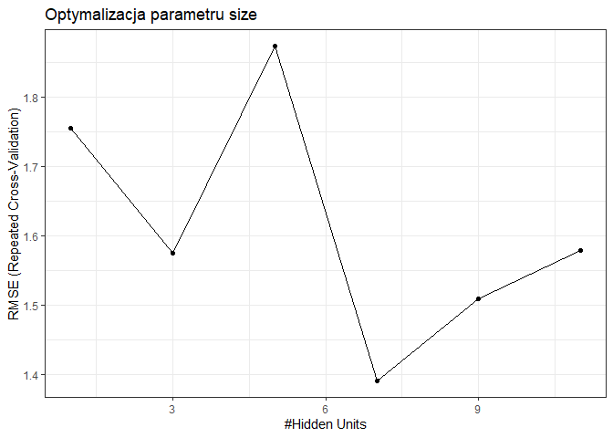

```r
ggplot(mlp_model) + geom_line() + geom_point() + ggtitle("Optymalizacja parametru size") + theme_bw()
```

#### 0.9.4.2 Zbiór testowy

```r
mlp_predicted <- predict(mlp_model, testing)
postResample(pred = mlp_predicted, obs = testing$length)
```

```
##      RMSE  Rsquared       MAE
## 1.4228627 0.3381934 1.1238576
```

### 0.9.5 Porównanie

```r
resamps <- resamples(list(linear_regression=lm_model,
                          random_forest=rf_model,
                          multi_layer_perceptron=mlp_model))

summary(resamps)
```

```
##
## Call:
## summary.resamples(object = resamps)
##
## Models: linear_regression, random_forest, multi_layer_perceptron
## Number of resamples: 10
##
## MAE
##                             Min.   1st Qu.    Median      Mean   3rd Qu.
## linear_regression      1.1403137 1.1458724 1.1483319 1.1483098 1.1506186
## random_forest          0.9356693 0.9369975 0.9407977 0.9409106 0.9447922
## multi_layer_perceptron 1.0436609 1.0556413 1.0903797 1.1061728 1.1151804
##                             Max. NA's
## linear_regression      1.1562232    0
## random_forest          0.9460241    0
## multi_layer_perceptron 1.2942315    0
##
## RMSE
##                            Min.  1st Qu.   Median     Mean  3rd Qu.     Max.
## linear_regression      1.425434 1.430785 1.434974 1.434893 1.439159 1.444148
## random_forest          1.183179 1.185739 1.188764 1.189240 1.193272 1.194056
## multi_layer_perceptron 1.318476 1.332862 1.373420 1.391493 1.403988 1.597455
##                        NA's
## linear_regression         0
## random_forest             0
## multi_layer_perceptron    0
##
## Rsquared
##                             Min.   1st Qu.    Median      Mean   3rd Qu.
## linear_regression      0.2409742 0.2462822 0.2472309 0.2472228 0.2481520
## random_forest          0.4776207 0.4810116 0.4825562 0.4828947 0.4848301
## multi_layer_perceptron 0.3340844 0.3574876 0.3635828 0.3686452 0.3852405
##                             Max. NA's
## linear_regression      0.2534518    0
## random_forest          0.4879880    0
## multi_layer_perceptron 0.4005753    0
```

Powyżej widzimy porównanie trzech utworzonych regreserów. Najlepszy wynik został osiągnięty przez **random forest** - ma on najmniejszą wartość *RMSE* oraz największą wartość *R-squared*.

## 0.10 Analiza ważności atrybutów modelu regresji

```r
varImp(rf_model)
```

```
## rf variable importance
##
##       Overall
## sst   100.000
## fbar   21.397
## lcop1  13.882
## nao     4.609
## chel1   0.000
```

Atrybut, od którego długość śledzia jest najbardziej zależna w naszym regresorze, to *sst* - czyli temperatura przy powierzchni wody. Ponieważ są skorelowane ujemne, to oznacza to, że wzrost temperatury wpływa na zmniejszanie się długości śledzia. Możemy przypuszczać, że globalne ocieplenie wpływa na podwyższenie temperatury wód, a co za tym idzie, ma wpływ na karłowacenie śledzi.

Trzeci atrybut pod względem ważności to jest *lcop1*, czyli dostępność jednego z rodzajów planktonu. Również są skorelowane dodatnie, więc ograniczona dostępność do tego rodzaju pożywienia również negatywnie wpływa na rozmiar śledzi. Ograniczenie dostępności tego rodzaju planktonu również może wynikać z globalnego ocieplenia lub przez działalność człowieka, przez to może mieć mniej korzystne warunki do rozwijania.

W naszym regresorze atrybut *nao* (oscylacja północnoatlantycka) ma niewielki wpływ, a *chel1* (dostępność określonego gatunku planktonu) zerowy.

## 0.11 Istniejące wyniki badań w literaturze naukowej

Nasze wnioski pokrywają się z literaturą naukową i dotychczasowymi wynikami badań na dany temat. Przykładowo Tanasichuk (1997) w swojej pracy opisuje wpływ klimatu oceanicznego na wzrost śledzia pacyficznego i jego wnioski są podobne. Również pisze, że to wzrost temperatury oceanów wpływa na zmniejszającą się długość śledzi.

Tanasichuk, RW. 1997. “Influence of Biomass and Ocean Climate on the Growth of Pacific Herring (Clupea Pallasi) from the Southwest Coast of Vancouver Island.” *Canadian Journal of Fisheries and Aquatic Sciences*. NRC Research Press Ottawa, Canada.